# MT: Model-based Adjustments for Non-concurrent Comparisons in Platform Trials - preliminary simulations

Pavla Krotka, Marta Bofill Roig

2023-04-12

# 1 Introduction

The following preliminary simulation study aims to explore different approaches to perform treatment-control comparisons using non-concurrent controls (NCC), where the time trend is modeled using fixed effect models, mixed effect models and splines. In the considered scenarios, continuous endpoints are assumed.

# 2 Investigated models

**Fixed effect models:**

- with period adjustment
- with calendar time adjustment

**Mixed effect models:**

- with period adjustment
- with calendar time adjustment
- with period adjustment and AR1 covariance structure
- with calendar time adjustment and AR1 covariance structure

**Spline regression:**

- polynomial splines with knots placed according to periods
- polynomial splines with knots placed according to calendar times
- piecewise polynomials (discontinuous) per period
- piecewise polynomial (discontinuous) per calendar time

# 3 Time trend patterns

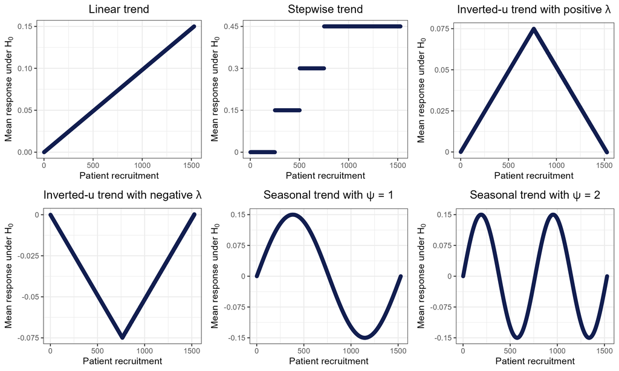

# 4 Scenario with 4 arms

- 4 experimental treatment arms
- $n=250$
- equal time trend - $\lambda \in [-0.5; 0.5]$
- entry times $d_i = 250 \cdot (i-1)$
- $\theta_k=0.25$ under $H_1$
- linear, stepwise (jump only when new arm enters), inverted u ($N_{peak}=750$) and seasonal ($\psi=1,2$) time trends
- inference for 3rd treatment arm

## 4.1 Overview

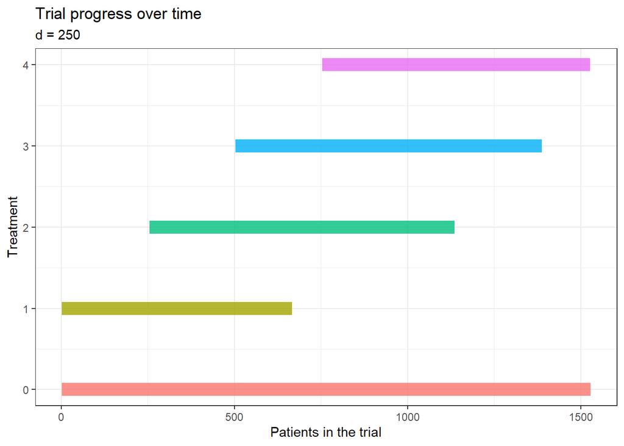

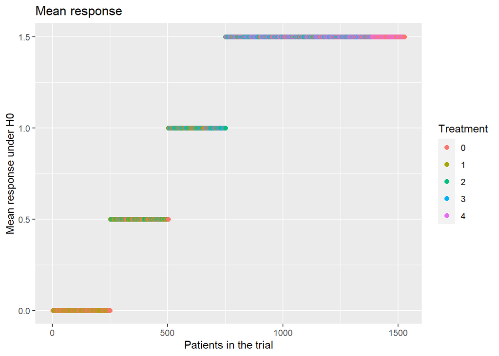

## 4.2 Results

### 4.2.1 Period vs. calendar time adjustment

#### 4.2.1.1 Fixed effects models

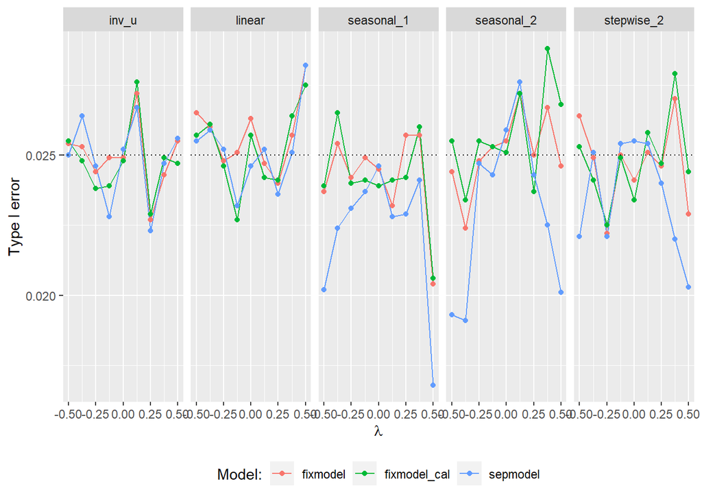

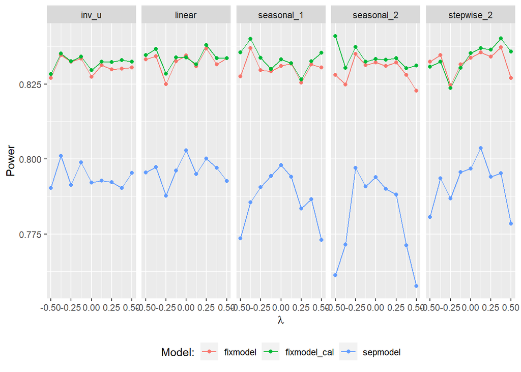

#### 4.2.1.2 Mixed effects models

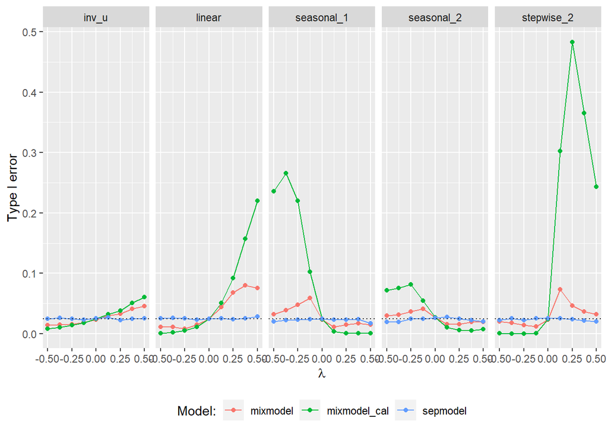

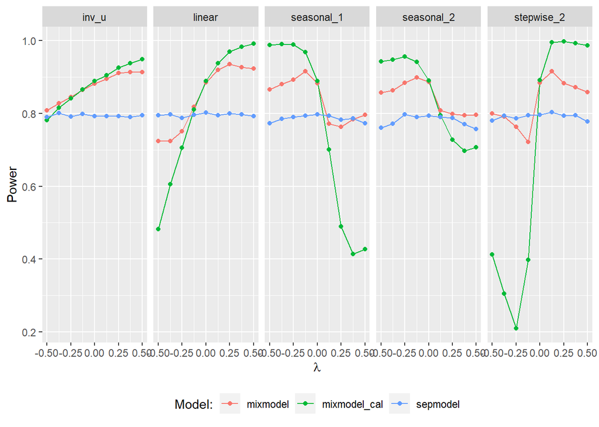

#### 4.2.1.3 Mixed effects models with AR1

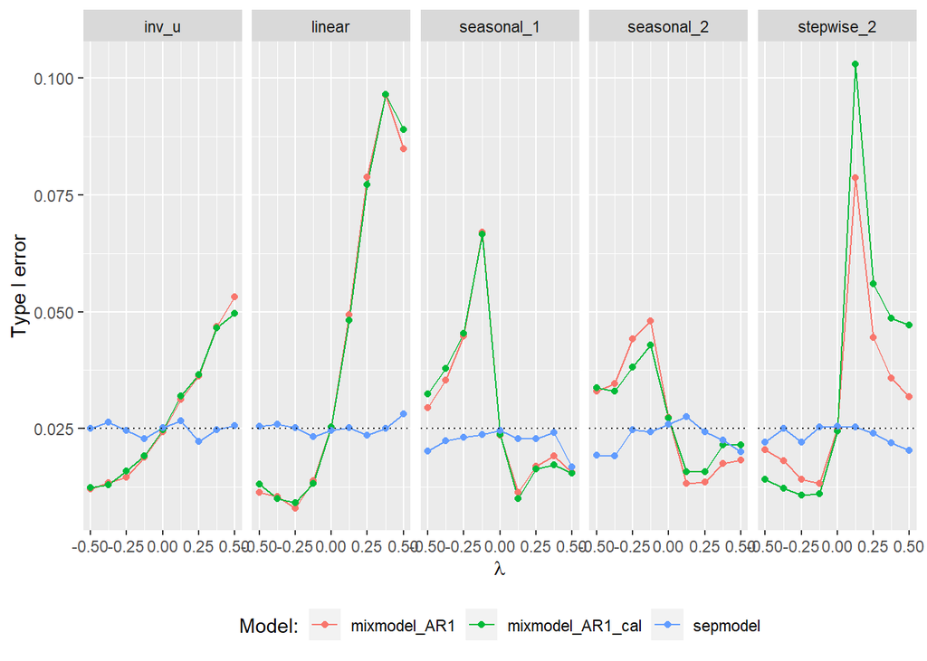

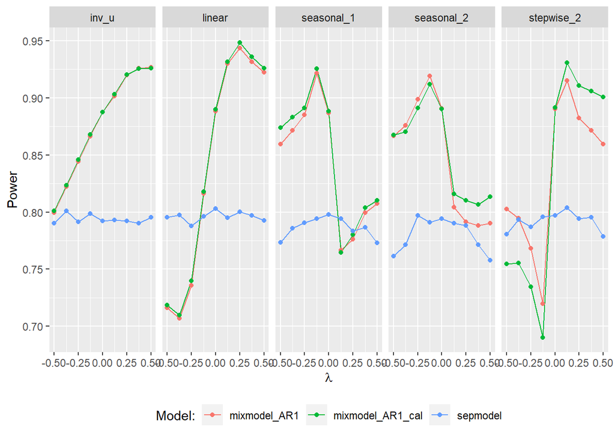

### 4.2.2 Different lengths of calendar time interval

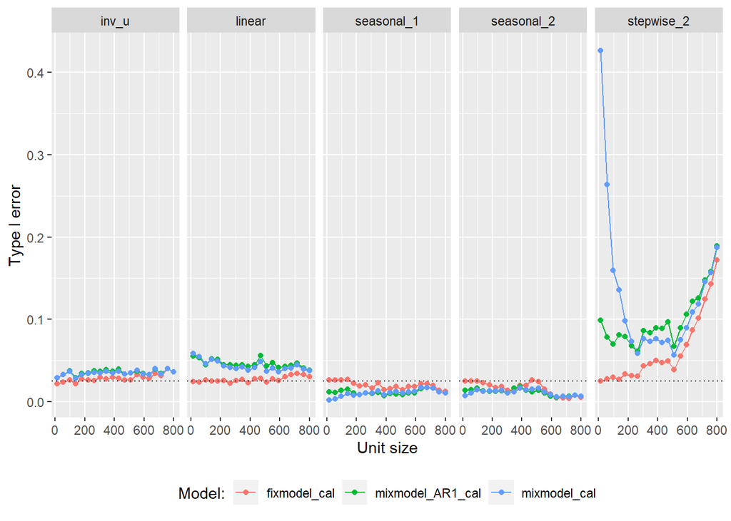

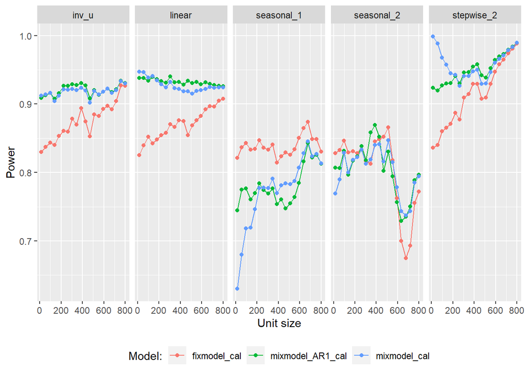

# 5 Scenario with 7 arms

## 5.1 Overview

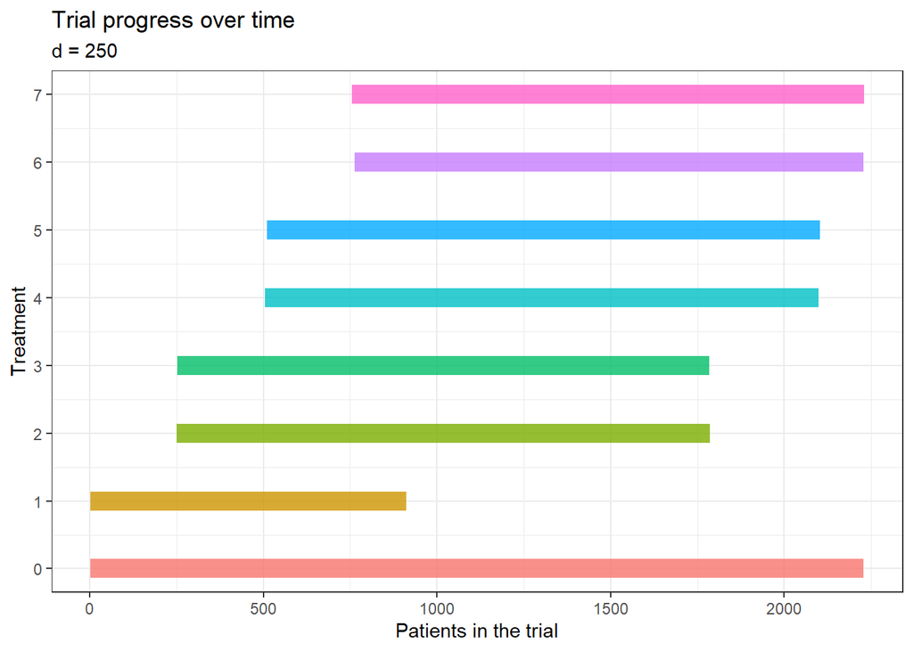

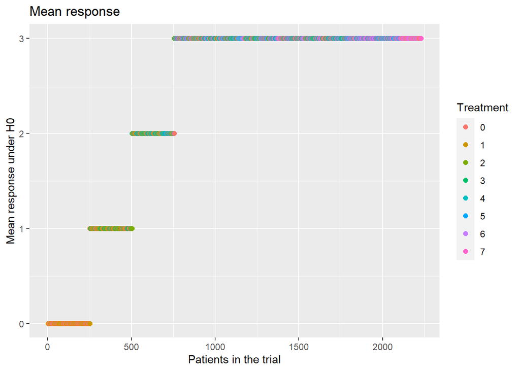

## 5.2 Results

### 5.2.1 Linear polynomials

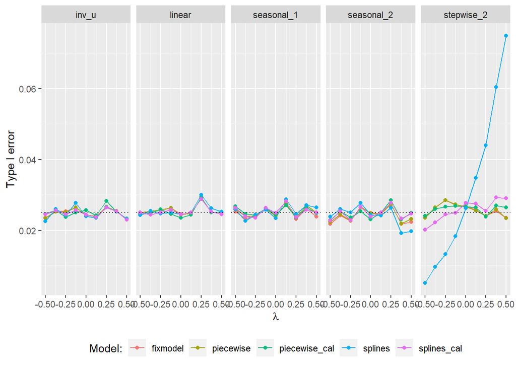

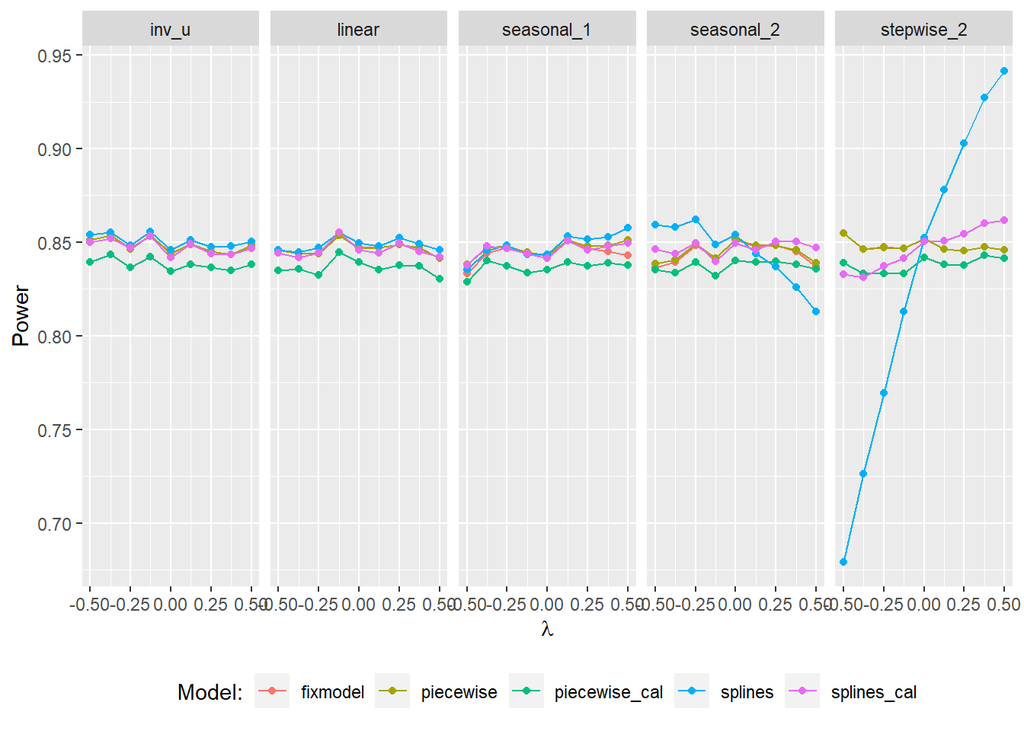

### 5.2.2 Quadratic polynomials

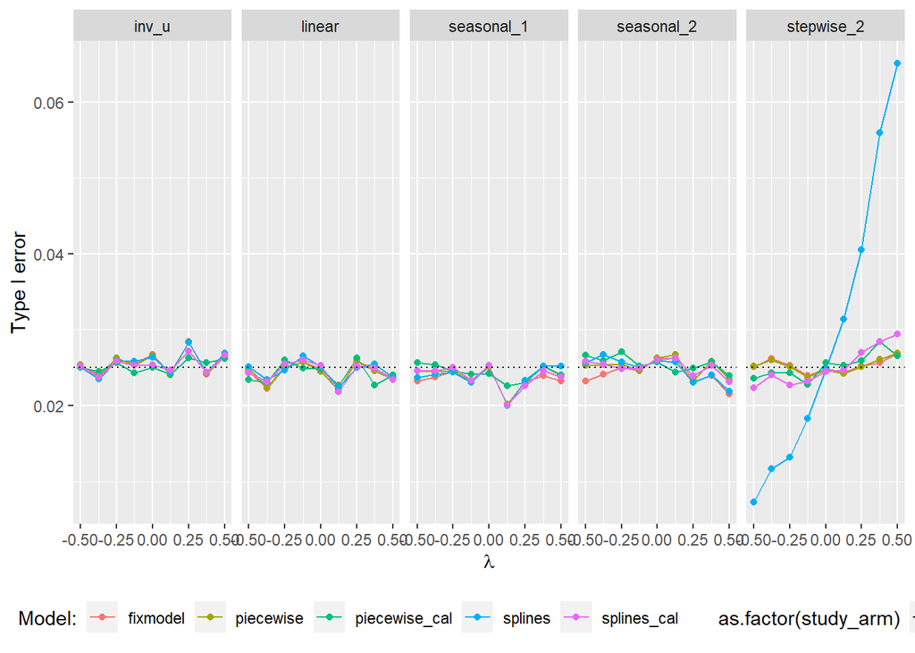

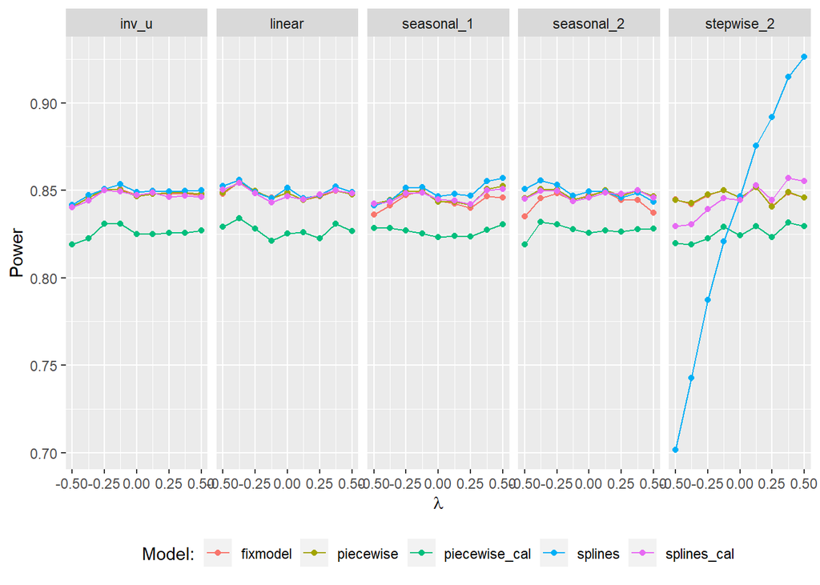

### 5.2.3 Cubic polynomials

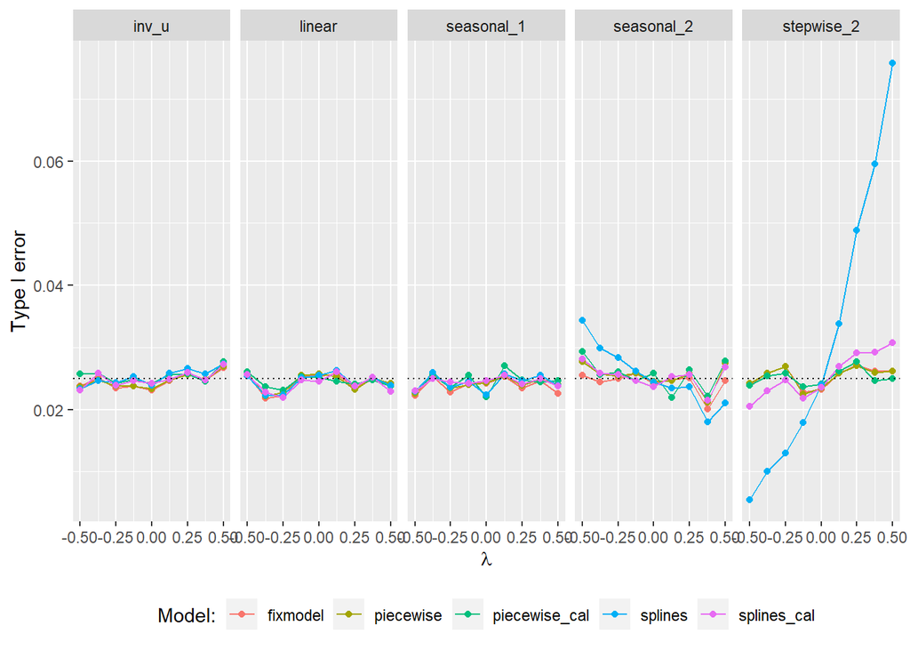

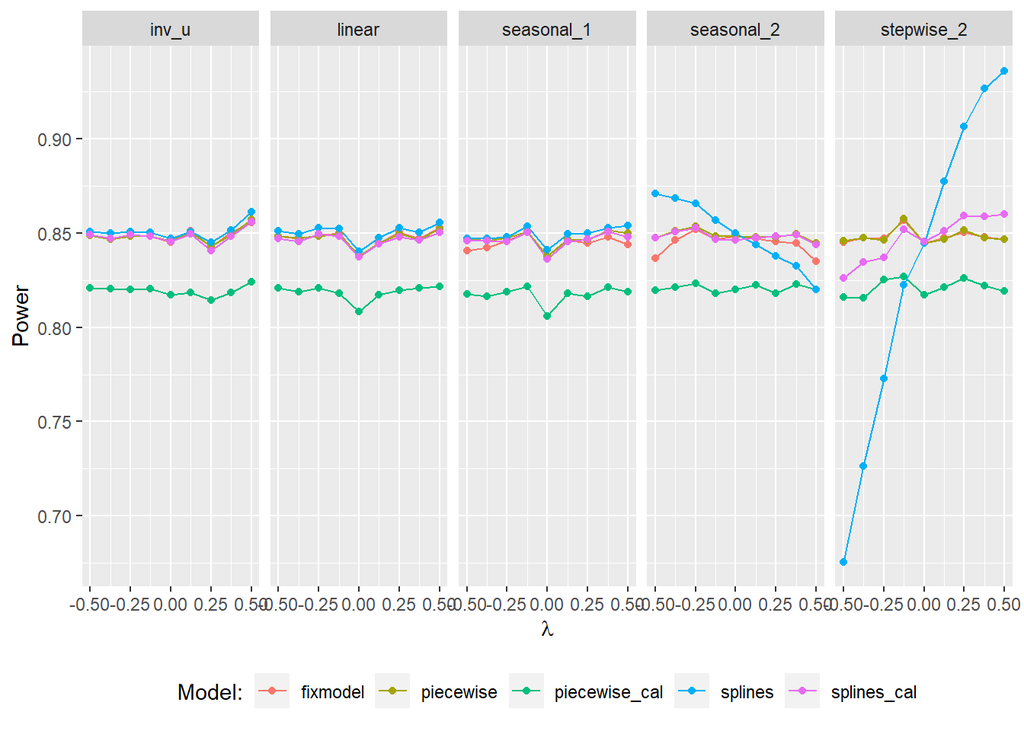

# 6 Plots presentation - Master’s seminar

## 6.1 Periods vs. calendar time

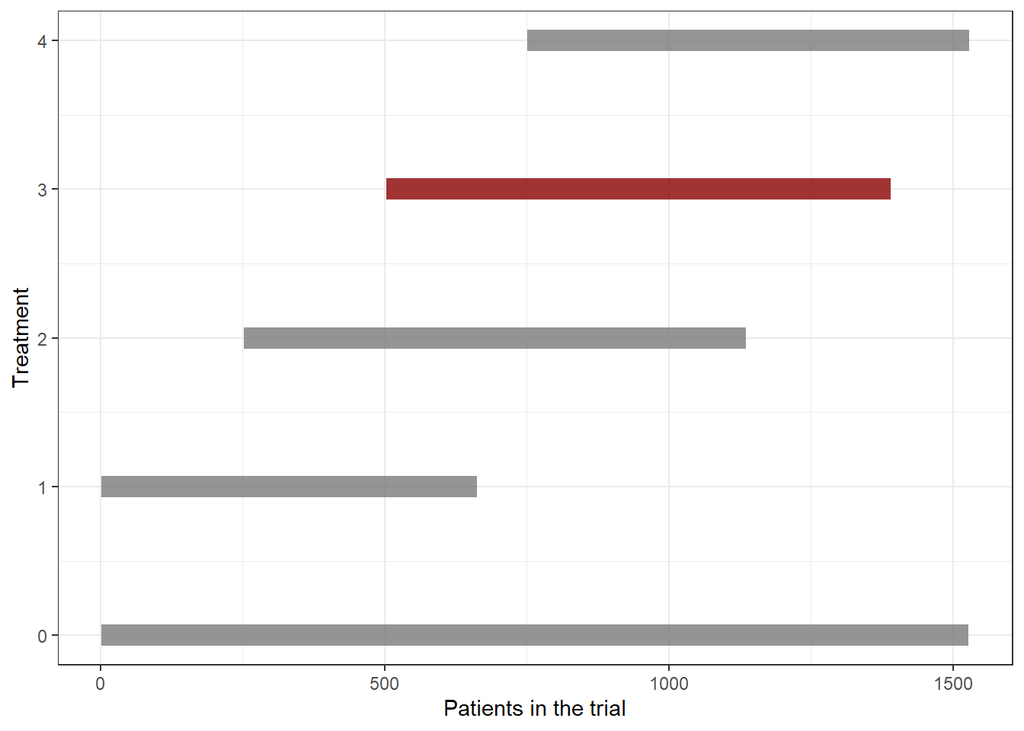

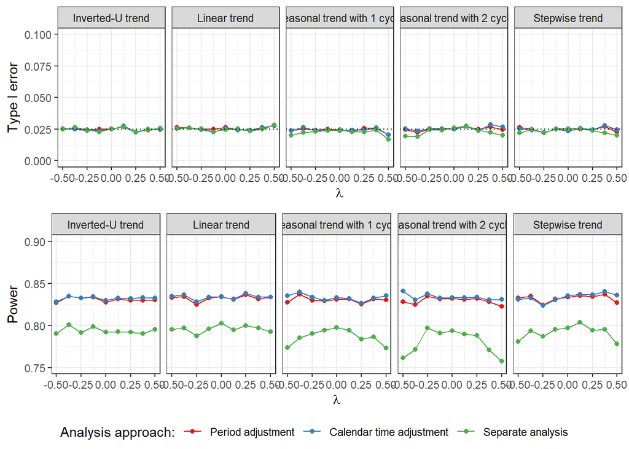

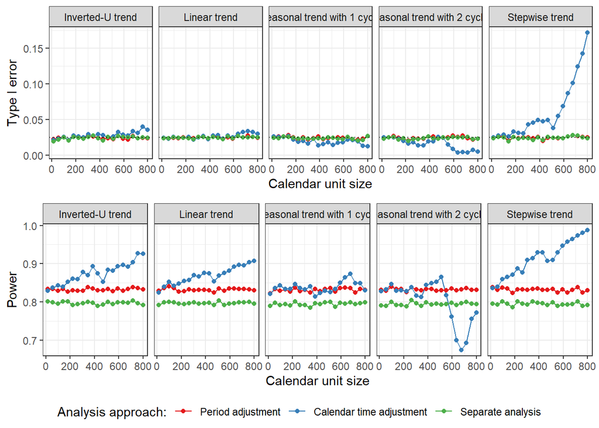

## 6.2 Mixed models

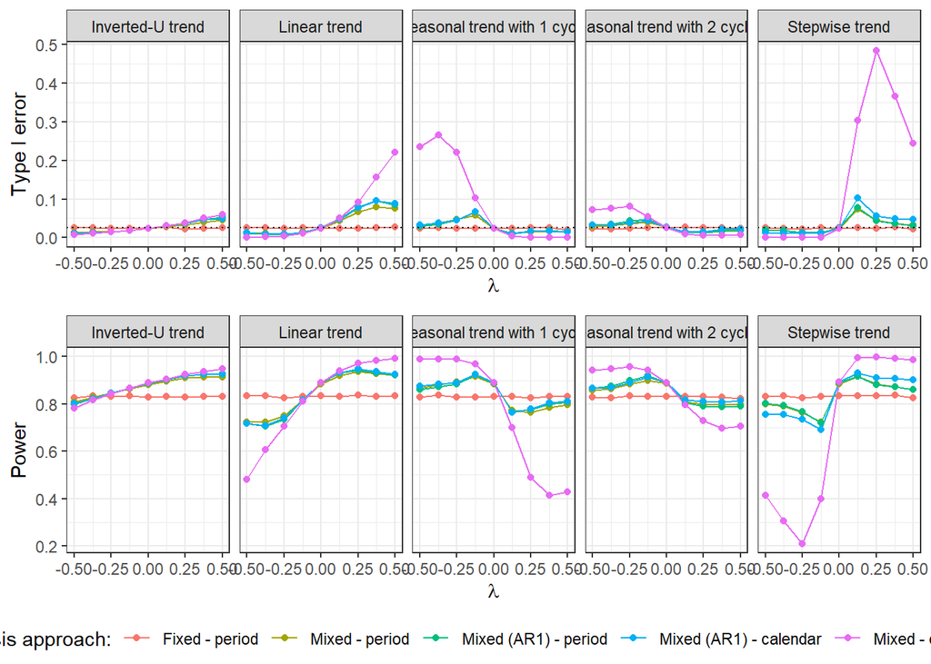

## 6.3 Splines

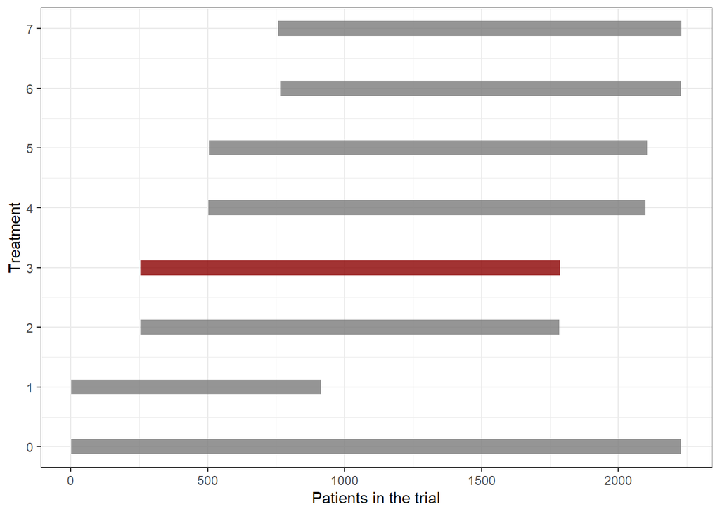

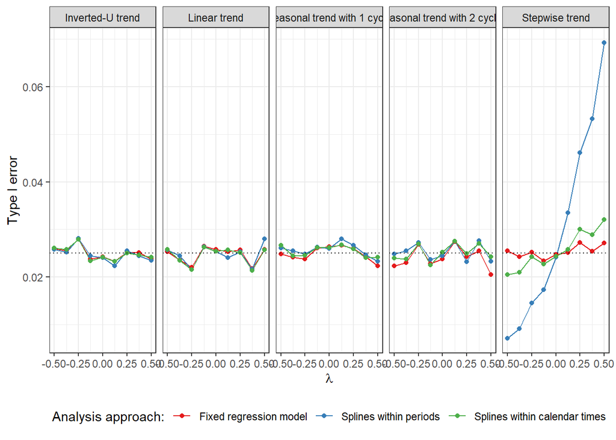

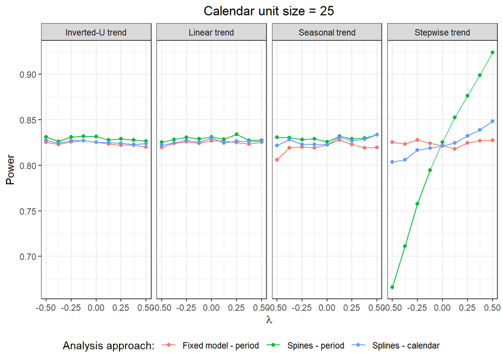

## 6.4 All scenarios

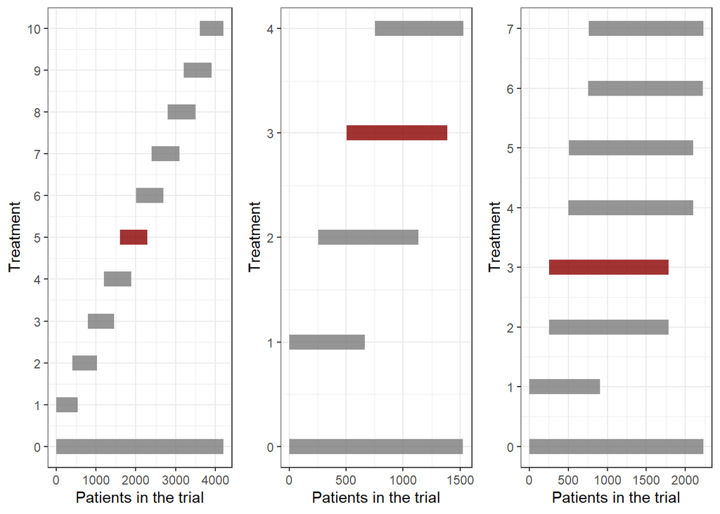